# Weekly Progress Report

# Stage III: Modeling, Classification and Metrics

In this next section, we will use the KNN algorithm to find the best K for a label. As this is a placeholder for future use, a good question to use this for is:

How can we classify a subjects health by having thresholds of poor, unsatisfactory, neutral, satisfactory or excellent?

To measure this hypothetical threshold, we would use how closely or different the training data is from testing. This was explored in the previous stage, and is required to be able to have a label to predict for in KNN.

```
## Session Cluster Distribution (%):
```

```
##
##        1        2
## 54.28571 45.71429
```

```
##
## Training Cluster Distribution (%):
```

```
##
##        1        2
## 57.14286 42.85714
```

```
##
## Session Cluster Centers (scaled):
```

```
##   Temperature   Moisture      Light Conductivity
## 1   0.6987607  0.1195229 -0.1362538    0.6844092
## 2  -0.8297783 -0.1419334  0.1618014   -0.8127359
```

```
##
## Training Cluster Centers (scaled):
```

```
##   Temperature   Moisture      Light Conductivity
## 1   0.2393013  0.7419636 -0.7206564    0.3206796
## 2  -0.3190684 -0.9892848  0.9608752   -0.4275727
```

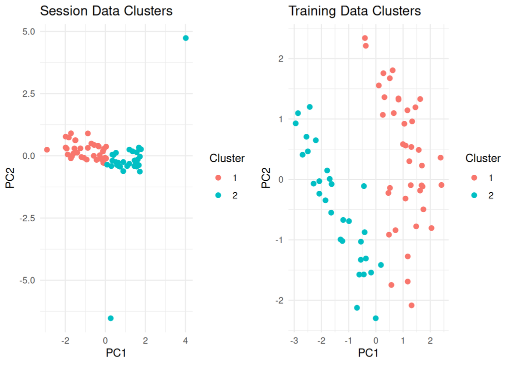

In order to begin preprocessing and find the right k, we will only keep the relevant features and label the cluster. This analysis uses the session data as testing data and the generated ideal conditions as the training data.

### Method 1: Built in knn() Function

```r
# Select numeric features and the cluster label
features_train <- training_data[, c("Temperature", "Moisture", "Light", "Conductivity")]
labels_train <- as.factor(training_data$Cluster)

test_features <- session_data[, c("Temperature", "Moisture", "Light", "Conductivity")]
labels_test <- as.factor(session_data$Cluster)
```

Normalizing the data will help scale larger values down to a comparable size.

```r
# Normalize (scale) the features
features_train_scaled <- as.data.frame(scale(features_train))
test_features_scaled <- as.data.frame(scale(test_features))
```

For our train/test split,

```r
train_features <- features_train_scaled
train_labels <- labels_train
```

Now we’ll proceed with modeling KNN and evaluating its performance. Before we start though, this cross correlation data needs to be fitted a bit more in order to pass through the KNN model.

```r
# Make sure train and test sets have the same number of rows as their respective labels
min_train_rows <- min(nrow(train_features), length(train_labels))
min_test_rows <- min(nrow(test_features), length(labels_test))

# Trim all data to match
train_features <- train_features[1:min_train_rows, ]
train_labels <- train_labels[1:min_train_rows]
test_features <- test_features[1:min_test_rows, ]
labels_test <- labels_test[1:min_test_rows]

# Convert labels to factors after trimming
train_labels <- as.factor(train_labels)
labels_test <- as.factor(labels_test)
```

```r
library(class)

# Training the KNN model
k_value <- 3  # You can experiment with different values of k
knn_model <- knn(train_features, test_features, train_labels, k = k_value)
# Evaluate the model
confusion_matrix <- table(Predicted = knn_model, Actual = labels_test)
accuracy <- sum(diag(confusion_matrix)) / sum(confusion_matrix)

cat("Accuracy on Session Data (Test Data):", accuracy)
```

```
## Accuracy on Session Data (Test Data): 0.4571429
```